# Sedimentary Facies

Dr. Ahmad Redaa

2025-07-20

# Learning Objectives

- Understand what sedimentary facies are and why they matter.
- Recognize key characteristics of sandstone, shale, and limestone facies.
- Distinguish between lithofacies, biofacies, and ichnofacies.-
- Relate facies to depositional environments.

# What is a Sedimentary Facies?

- A body of rock with a distinct set of physical, chemical, and biological attributes.
- Represents the conditions of deposition in a specific environment.
- It can be a part of a bed, a whole bed or several beds
- Refers to all of the characteristics of a particular rock unit.

# Key Characteristics of Facies

- Grain size & sorting (e.g., sand vs. clay)
- Sedimentary structures (cross‑bedding, ripple marks, laminations)
- Color and texture
- Fossil content and trace fossils
- Mineralogy / composition
- Geometry and thickness

# Facies Patterns

## Groups of facies commonly show patterns.

- **Proximal Facies** (near the source) tend to be coarse grained, reflecting high energy regimes.
- **Distal Facies** (far from the source) tend to be finer grained, reflecting low energy regimes.
- This pattern is seen upstream to downstream in rivers and from onshore to offshore in coastal areas.
- Facies are arranged according to the spatial distribution of depositional environments.

# Sedimentary Facies

[figure not shown]

Source: [https://www.docsity.com](https://www.docsity.com/en/docs/sedimentary-facies-dynamic-earth-lecture-slides/209283/)

# Sandstone Facies

- Typical settings: Rivers, deltas, beaches, deserts.
- Medium‑ to coarse‑grained, often well‑sorted.
- Common structures: Trough cross‑bedding, ripple marks.
- May grade laterally or vertically into shale or conglomerate facies.

# Shale Facies

- Typical settings: Deep marine basins, floodplains, quiet lakes.
- Very fine‑grained, fissile, often laminated.
- May preserve varves (seasonal couplets) and organic matter.
- Excellent seal rocks in petroleum systems.

# Limestone Facies

- Typical settings: Warm, shallow marine shelves, reefs, lagoons.
- Dominated by calcite (CaCO₃); often rich in fossils.
- Structures include bedding planes, bioturbation, reefal frameworks.
- Key reservoir facies when fractured or dolomitized.

# Facies Classification Overview

- **Lithofacies:** Based on rock’s physical & mineralogical properties.
- **Biofacies:** Defined by fossil assemblages (e.g., coral biofacies).
- **Ichnofacies:** Defined by trace‑fossil suites reflecting organism behavior.

# Lithofacies

- Example: Cross‑bedded quartz sandstone indicates high‑energy flow. = Use grain size, sorting, mineral content to interpret energy & source.

# Biofacies

- Example: Brachiopod‑rich shale suggests a calm marine shelf.
- Reveals paleoecology, water depth, salinity, and nutrient levels.

# Ichnofacies

- Example: Skolithos ichnofacies → vertical burrows in sandy shorelines.
- Provides insight into oxygenation, substrate consistency, and energy.

# Facies Migration

- Facies migrate through space and time
- Migration is in response to environmental factors
  - Sediment supply
  - Sea level change
  - Subsidence
- Facies become stacked during migration
- A single facies is likely to be different ages in different locations

# Walther’s Law

## a vertical sequence of facies will be the product of a series of depositional environments which lay laterally adjacent to each other

[Watch this video on YouTube to learn more about Walther’s Law](https://www.youtube.com/watch?v=afWDaaAd5ck)

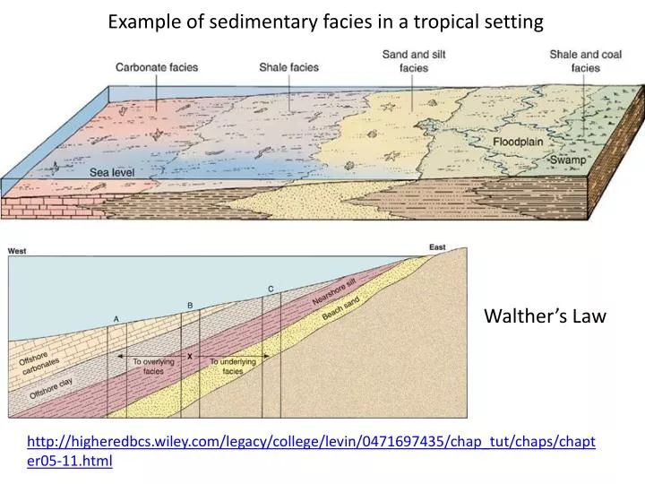

Source: [https://www.slideserve.com](https://www.slideserve.com/varsha/example-of-sedimentary-facies-in-a-tropical-setting)